# Chapter 7 Exercises

Eugene Yan

1 March 2015

### 1.a

For $x \le \xi$, $f_1(x)$ has coefficients $a_1 = \beta_0, b_1 = \beta_1, c_1 = \beta_2, d_1 = \beta_3$.

### 1.b

For $x \gt \xi$, $f(x)$ has the form of: $\beta_0 + \beta_1 x + \beta_2 x^2 + \beta_3 x^3 + \beta_4 (x - \xi)^3 \ = \beta_0 + \beta_1 x + \beta_2 x^2 + \beta_3 x^3 + \beta_4 (x^3 - 3 x^2 \xi + 3 x \xi^2 - \xi^3) \ = (\beta_0 - \beta_4 \xi^3) + (\beta_1 + 3 \beta_4 \xi^2) x + (\beta_2 - 3 \beta_4 \xi) x^2 + (\beta_3 + \beta_4) x^3$

Thus, $a_2 = \beta_0 - \beta_4 \xi^3, b_2 = \beta_1 + 3 \beta_4 \xi^2, c_2 = \beta_2 - 3 \beta_4 \xi, d_2 = \beta_3 + \beta_4$.

### 1.c

$f_1(\xi) = \beta_0 + \beta_1 \xi + \beta_2 \xi^2 + \beta_3 \xi^3 \ f_2(\xi) = (\beta_0 - \beta_4 \xi^3) + (\beta_1 + 3 \beta_4 \xi^2) \xi + (\beta_2 - 3 \beta_4 \xi) \xi^2 + (\beta_3 + \beta_4) \xi^3 \ = \beta_0 - \beta_4 \xi^3 + \beta_1 \xi + 3 \beta_4 \xi^3 + \beta_2 \xi^2 - 3 \beta_4 \xi^3 + \beta_3 \xi^3 + \beta_4 \xi^3 \ = \beta_0 + \beta_1 \xi + \beta_2 \xi^2 + 3 \beta_4 \xi^3 - 3 \beta_4 \xi^3 + \beta_3 \xi^3 + \beta_4 \xi^3 - \beta_4 \xi^3 \ = \beta_0 + \beta_1 \xi + \beta_2 \xi^2 + \beta_3 \xi^3$

### 1.d

$f'(x) = b_1 + 2 c_1 x + 3 d_1 x^2 \ f_1'(\xi) = \beta_1 + 2 \beta_2 \xi + 3 \beta_3 \xi^2 \ f_2'(\xi) = \beta_1 + 3 \beta_4 \xi^2 + 2 (\beta_2 - 3 \beta_4 \xi) \xi + 3 (\beta_3 + \beta_4) \xi^2 \ = \beta_1 + 3 \beta_4 \xi^2 + 2 \beta_2 \xi - 6 \beta_4 \xi^2 + 3 \beta_3 \xi^2 + 3 \beta_4 \xi^2 \ = \beta_1 + 2 \beta_2 \xi + 3 \beta_3 \xi^2 + 3 \beta_4 \xi^2 + 3 \beta_4 \xi^2 - 6 \beta_4 \xi^2 \ = \beta_1 + 2 \beta_2 \xi + 3 \beta_3 \xi^2$

### 1.e

$f''(x) = 2 c_1 + 6 d_1 x \ f_1''(\xi) = 2 \beta_2 + 6 \beta_3 \xi \ f_2''(\xi) = 2 (\beta_2 - 3 \beta_4 \xi) + 6 (\beta_3 + \beta_4) \xi \ = 2 \beta_2 + 6 \beta_3 \xi$

### 2.a

$g(x) = k$ because RSS term is ignored and $g(x) = k$ would minimize the area under the curve of $g^{(0)}$.

### 2.b

$g(x) \alpha x^2$. $g(x)$ would be quadratic to minimize the area under the curve of its first derivative.

### 2.c

$g(x) \alpha x^3$. $g(x)$ would be cubic to minimize the area under the curve of its second derivative. See Eqn 7.11.

### 2.d

$g(x) \alpha x^4$. $g(x)$ would be quartic to minimize the area under the curve of its third derivative.

### 2.e

The penalty term no longer matters. This is the formula for linear regression, to choose g based on minimizing RSS.

### 3

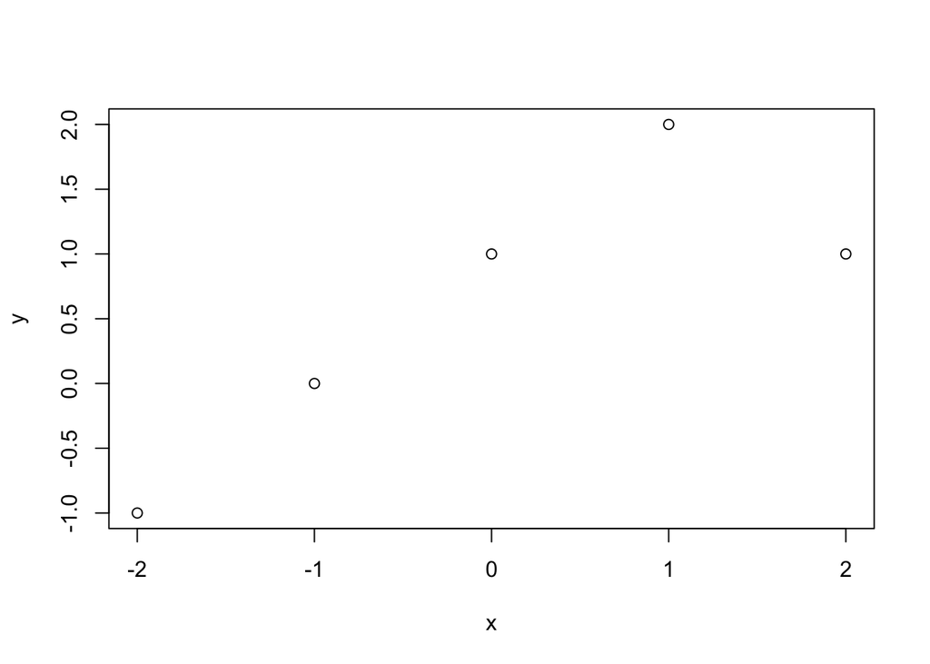

```r
x = -2:2
y = 1 + x + -2 * (x-1)^2 * I(x>1)
plot(x, y)
```

### 4

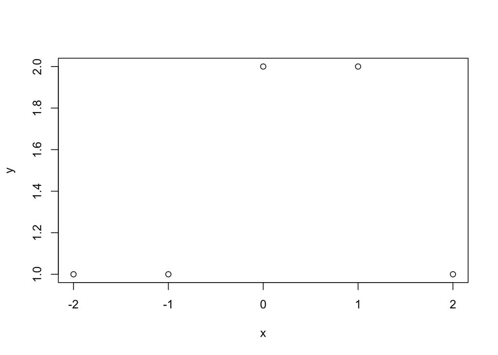

```r
x = -2:2
y = c(1 + 0 + 0, # x = -2
      1 + 0 + 0, # x = -1
      1 + 1 + 0, # x = 0
      1 + (1-0) + 0, # x = 1
      1 + (1-1) + 0 # x =2
      )
plot(x,y)
```

### 5.a

We’d expect $\hat{g_2}$ to have the smaller training RSS because it will be a higher order polynomial due to the order of the derivative penalty function.

### 5.b

We’d expect $\hat{g_1}$ to have the smaller test RSS because $\hat{g_2}$ could overfit with the extra degree of freedom.

### 5.c

Trick question. $\hat{g_1} = \hat{g_2}$ when $\lambda = 0$.